# NHP Reference Values - RNA-seq

Rodrigo Arcoverde Cerveira

2025-03-25

# Load libraries

```r
#Load libraries
#if you do not have libraries, they are located in either CRAN or Bioconductor
library(clusterProfiler)
library(psych)
library(dplyr)
library(ggplot2)
library(ggsci)
library(DESeq2)
library(RColorBrewer)
library(pheatmap)
library(factoextra)
library(ggpubr)
library(GSVA)
library(ReactomePA)
library(enrichplot)

nodeid.tbl_tree <- utils::getFromNamespace("nodeid.tbl_tree", "tidytree")
rootnode.tbl_tree <- utils::getFromNamespace("rootnode.tbl_tree", "tidytree")
offspring.tbl_tree <- utils::getFromNamespace("offspring.tbl_tree", "tidytree")
offspring.tbl_tree_item <- utils::getFromNamespace(".offspring.tbl_tree_item", "tidytree")
child.tbl_tree <- utils::getFromNamespace("child.tbl_tree", "tidytree")
parent.tbl_tree <- utils::getFromNamespace("parent.tbl_tree", "tidytree")
```

# Load data

```r
# read fold change measurements

fc_biochem <- read.csv("../data/fold_changes/fold_changes_bioch.csv") %>%  dplyr::select(where(~!all(is.na(.x))))

selected_fc <- read.csv2("../data/fold_changes/Updated-24h_foldchange.csv", header = TRUE, sep = ";")
colnames(selected_fc) <- gsub("Foldcha_", "", colnames(selected_fc))

#reading data
counts_raw_cd40 <- data.table::fread("../data/nf-core_rnaseq/CD40_project/star_salmon/salmon.merged.gene_counts.tsv", header = TRUE, sep = "\t") %>%  as.data.frame() %>%
  select(-gene_id)

counts_raw_novavax <- data.table::fread("../data/nf-core_rnaseq/novavax/star_salmon/salmon.merged.gene_counts.tsv", header = TRUE, sep = "\t") %>%  as.data.frame() %>%
  select(-gene_id, gene_name)
counts_raw <- cbind(counts_raw_cd40, counts_raw_novavax[,-1])

# load normalized transcripts per million
# rewrite the code below to load both the CD40 and novavax data TPM
tpm_cd40 <- data.table::fread("../data/nf-core_rnaseq/CD40_project/star_salmon/salmon.merged.gene_tpm.tsv", sep = "\t", header = TRUE) %>%
  as.data.frame() %>%
  select(-gene_id)
tpm_novavax <- data.table::fread("../data/nf-core_rnaseq/novavax/star_salmon/salmon.merged.gene_tpm.tsv", sep = "\t", header = TRUE) %>%
  as.data.frame() %>%
  select(-gene_id, gene_name)
tpm <- cbind(tpm_cd40, tpm_novavax[,-1])


# load metadata
metadata <- read.csv("../data/nf-core_rnaseq/merged_metadata.csv", header = TRUE, sep = ",") %>%
  filter(tissue == "Blood", comparator != "D79", batch == "novavax") %>%
  mutate(sample_comparator = paste(ID, conditions, sep = "_"))


## aggregate and sum up genes with same gene symbol, which were basically non-coding RNAs
counts_raw <- aggregate(counts_raw[,-1], list(gene_name=counts_raw[,1]), FUN = sum)
rownames(counts_raw) <- counts_raw$gene_name
counts_raw <- dplyr::select(counts_raw, -c(gene_name))

tpm <- aggregate(tpm[,-1], list(gene_name=tpm[,1]), FUN = sum)
rownames(tpm) <- tpm$gene_name
tpm <- dplyr::select(tpm, -c(gene_name))

# filter only the samples that are in the metadata for both counts_raw and tpm
counts_raw <- counts_raw[, pmatch(metadata$sample, colnames(counts_raw))]
colnames(counts_raw) <- metadata$sample_comparator
tpm <- tpm[, pmatch(metadata$sample, colnames(tpm))]
colnames(tpm) <- metadata$sample_comparator
```

# Inspect data

Matching metadata to counts_raw and plotting the raw counts histogram for first visual inspection.

```r
#Synchonize count data with sample table
.match_metadata <- function(gene_count_table, metadata_df){
  gene_count_table <- gene_count_table[, pmatch(metadata_df$sample_comparator, colnames(gene_count_table))]
  colnames(gene_count_table) <- metadata_df$sample_comparator
  if(all(rownames(gene_count_table$sample_id) == colnames(gene_count_table))){
    print("All data column names are matching with metadata IDs")
  }else{print("Data column names do not match with metadata IDs")}
}
.match_metadata(counts_raw, metadata)
```

```
## [1] "All data column names are matching with metadata IDs"
```

```r
.match_metadata(tpm, metadata)
```

```
## [1] "All data column names are matching with metadata IDs"
```

```r
#Visualize distribution of raw counts w/ boxplot and density plot
{
  pdf(paste0(figures.dir,"/raw_counts_QC.pdf"), width = 10,  height = 8, compress = TRUE )
  rafalib::mypar(1,2,mar=c(10,3,3,2))
  boxplot(log2(as.matrix(counts_raw)+1),ylab=expression('Log'[2]~'Read counts'),las=2,main="Raw data")
  hist(log2(as.matrix(counts_raw)+1),ylab="",las=2,main="Raw data")
  par(mfrow=c(1,1))
  dev.off()
}
```

# Filtering data

Plot detection of genes across samples. All samples are more or less close to average so we don’t need to discard any samples.

```r
{
  pdf(paste0(figures.dir,"/number_detected_genes.pdf"), width = 10,  height = 8, compress = TRUE )
  par(mar=c(10,4,3,4))
  barplot(colSums(counts_raw>3),ylab="Number of detected genes",las=2)
  abline(h=median(colSums(counts_raw>3)))
  dev.off()
}
```

```r
#Filter low counts
keep_genes <- rowSums( counts_raw > 3 ) >= 2
counts_filtered<- counts_raw[keep_genes,]
sum(keep_genes)
```

```
## [1] 14221
```

# Plot gene of interest over time

Use the transcripts per million calculated by salmon to plot it.

```r
tpm <- tpm %>%
  as.data.frame() %>%
  tibble::rownames_to_column("gene_symbol")
colnames(tpm) <- gsub("_XY", "", colnames(tpm))

# select genes based on their oficial gene symbol that related to following proteins/enzymes/molecules ALT, GGT, ALP, TBIL, ALB, BUN, CHOL,BA

genes_of_interest <- c("GPT", "GGT1", "ALPL", "TBXAS1", "ALB", "ADAMTS13", "APOE", "BAAT" , "TNF", "IL6", "TGFB1", "IL1A", "IL1B", "CCL2", "IL10", "IFNG", "IL2","IL8", "IL18","NLRP3", "CASP7","CASP8","CASP4","CASP5", "P2RX7", "HMGB1", "PTGES2", "LDHA", "NFKB1", "NFKB2", "IL1RN")


for(i in seq_along(genes_of_interest)){
  name_gene <- genes_of_interest[i]
  print(name_gene)

  g1 <- tidyr::pivot_longer(tpm, !gene_symbol, values_to = "TPM") %>%
    filter(gene_symbol == name_gene) %>%
    tidyr::separate(name, into = c("ID","Comparator"), sep = "_") %>%
    mutate(Comparator = ifelse(Comparator == "D0", "Baseline", "24 hours"),
           Comparator = factor(Comparator, levels = c("Baseline", "24 hours")),
           project = ifelse(grepl("R1", ID), "cd40", "novavax")) %>%
    ggplot(aes(y = TPM, x = Comparator, group = ID, color = Comparator)) +
    labs(title = name_gene, y = "Transcripts per million\n(log 10)", x = "")+
    scale_y_log10(expand = expansion(mult = c(0.05, 0.15))) +
    stat_compare_means(paired = TRUE, method = "wilcox.test", comparisons = list(c("Baseline", "24 hours"))) +
    geom_boxplot(outlier.shape = NA, aes(group = Comparator)) +
    geom_point()+
    geom_line()+
    ggprism::theme_prism(base_fontface = "plain", base_size = 10, border = TRUE) +
    theme(aspect.ratio = 1, legend.position = "none") +
    scale_color_aaas()
  g1$theme[c("legend.text.align", "legend.title.align")] <- NULL

  ggsave(plot = g1, filename = paste0(figures.dir, "/", name_gene,".pdf"), width = 7, height = 7, units = "cm", dpi = 300)
}
```

```
## [1] "GPT"
```

```
## [1] "GGT1"
```

```
## [1] "ALPL"
```

```
## [1] "TBXAS1"
```

```
## [1] "ALB"
```

```
## [1] "ADAMTS13"
```

```
## [1] "APOE"
```

```
## [1] "BAAT"
```

```
## [1] "TNF"
```

```
## [1] "IL6"
```

```
## [1] "TGFB1"
```

```
## [1] "IL1A"
```

```
## [1] "IL1B"
```

```
## [1] "CCL2"
```

```
## [1] "IL10"
```

```
## [1] "IFNG"
```

```
## [1] "IL2"
```

```
## [1] "IL8"
```

```
## [1] "IL18"
```

```
## [1] "NLRP3"
```

```
## [1] "CASP7"
```

```
## [1] "CASP8"
```

```
## [1] "CASP4"
```

```
## [1] "CASP5"
```

```
## [1] "P2RX7"
```

```
## [1] "HMGB1"
```

```
## [1] "PTGES2"
```

```
## [1] "LDHA"
```

```
## [1] "NFKB1"
```

```
## [1] "NFKB2"
```

```
## [1] "IL1RN"
```

Plot detection rate across genes for raw and filtered counts

```r
{
  pdf(paste0(figures.dir,"/detection_rate_raw_filtered.pdf"), width = 10,  height = 8, compress = TRUE )
  par(mar=c(10,4,3,4))
  hist(rowSums(counts_raw>2))
  hist(rowSums(counts_filtered>2))
  par(mfrow=c(1,1))
  dev.off()
}
```

Plot distribution of the filtered counts

```r
{
  pdf(paste0(figures.dir,"/filtered_counts_distribution.pdf"), width = 10,  height = 8, compress = TRUE )
  rafalib::mypar(1,2,mar=c(10,3,3,2))
  boxplot(log2(as.matrix(counts_filtered)+1),ylab=expression('Log'[2]~'Read counts'),las=2,main="Filtered data")
  hist(log2(as.matrix(counts_filtered)+1),ylab="",las=2,main="Filtered data")
  par(mfrow=c(1,1))
  dev.off()
}
```

#### DESeq object creation and data QC

```r
# prepare for DESeq
metadata$conditions <- factor(metadata$conditions)
metadata$sex <- factor(metadata$sex)
metadata$batch <- factor(metadata$batch)

# create DESeq object
dds <- DESeqDataSetFromMatrix(countData = round(counts_filtered),
                              colData = metadata,
                              design =  ~ sex + conditions)

# Normalize with variance stabilizing transformation for later PCA and heatmap
counts_vst_normalized <- vst(dds, blind = TRUE)
```

Plot distribution of data after normalization

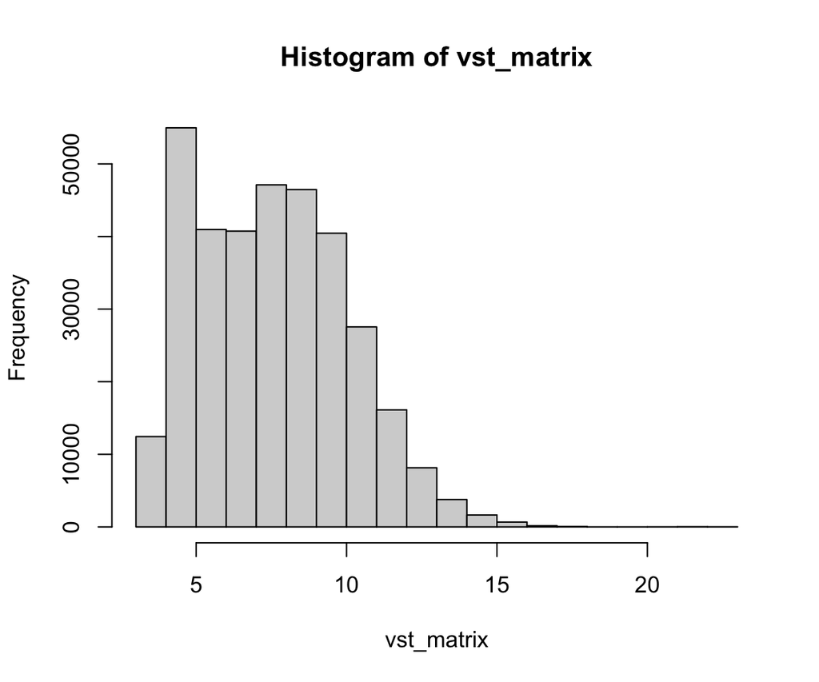

```r
# haven't decided which plots to use
vst_matrix <- assay(counts_vst_normalized)
#rlog_matrix <- assay(counts_rlog_normalized)
hist(vst_matrix)
```

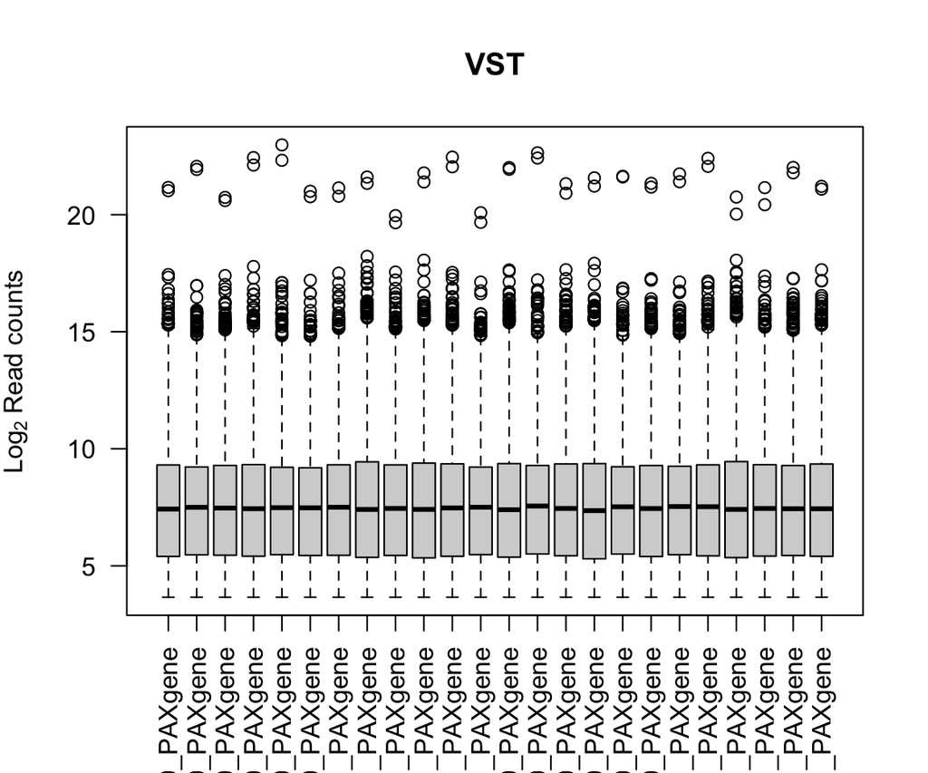

```r
#hist(rlog_matrix)
boxplot(vst_matrix ,ylab=expression('Log'[2]~'Read counts'),las=2,main="VST")
```

```r
#boxplot(rlog_matrix ,ylab=expression('Log'[2]~'Read counts'),las=2,main="rlog")
```

#### Heatmap

```r
# Sample heatmap
sampleDist <- cor(vst_matrix, method = "spearman")

Metadata <- data.frame(metadata$batch, metadata$comparator)
names(Metadata) <- c("Study","Dose")
rownames(Metadata) <- metadata$sample_comparator

# Plot heatmap
colors<-colorRampPalette(rev(brewer.pal(n=7,name="RdBu")))(255)

{
  pdf(paste0(figures.dir,"/heatmap.pdf"), width = 10,  height = 8, compress = TRUE )
 Heatmap <-  pheatmap(sampleDist,
           color = colors,
           clustering_distance_rows = as.dist(1 - sampleDist),
           clustering_distance_cols = as.dist(1 - sampleDist),
           show_rownames = F,
           show_colnames = F,
           clustering_method = "ward.D2",
           annotation_col = Metadata)
  par(mfrow=c(1,1))
  dev.off()
}
```

# Principal Component Analyais (PCA)

Dimensionality reduction for evaluating outliers and global sample clusters for both quality control but also for primary exploratory analysis.

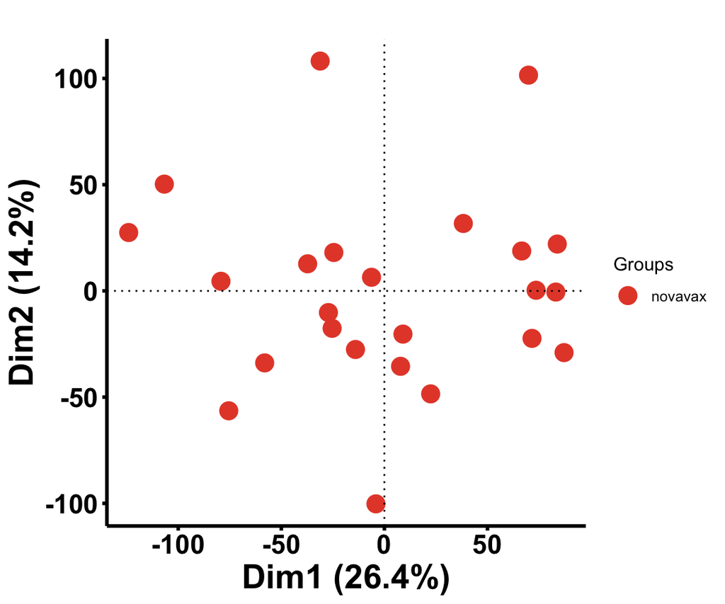

```r
#Sample PCA
pca <- t(assay(counts_vst_normalized))
order_names <- rownames(pca)
pca <- FactoMineR::PCA(pca, graph = FALSE)
metadata <- metadata[match(order_names, metadata$sample_comparator),]

fviz_pca_ind(pca,axes.linetype = "dotted",
             pointsize = 5,
             habillage = as.factor(metadata$batch),
             palette = "npg",
             label = metadata$ID,
             invisible="quali") +
  labs(title = "") +
  theme_minimal()+
  theme(axis.title = element_text(size = 20, face = "bold"),
        axis.text = element_text(size = 16, face = "bold", color = "black"),
        panel.grid = element_line("white"),
        axis.ticks = element_line(size = 1),
        axis.line = element_line(color = "black", size = 1))
```

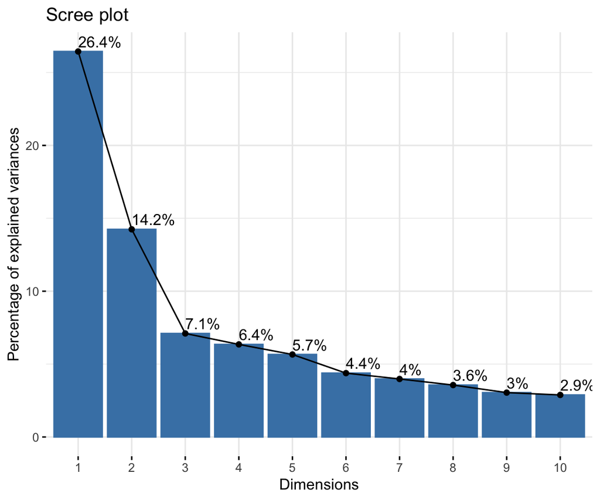

```r
## Plot how much each dimension explains
fviz_eig(pca, addlabels = TRUE)
```

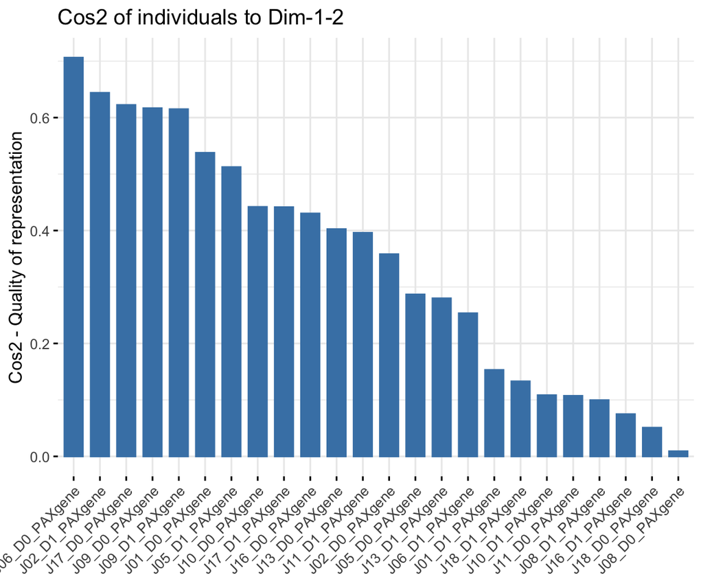

```r
fviz_cos2(pca, choice = "ind", axes = 1:2)
```

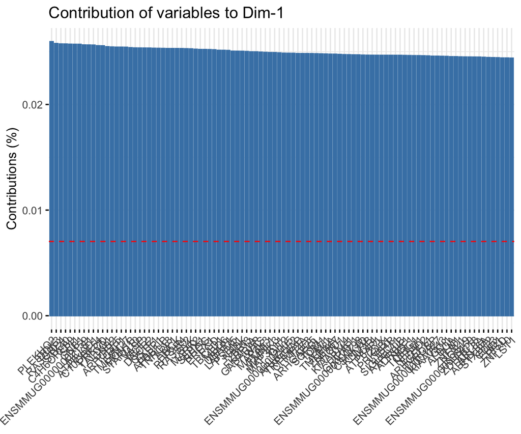

```r
## Explore which variables contribute the most for each PC
fviz_contrib(pca, choice = "var", axes = 1, top = 100)
```

# Statistical analysis and fitting DESeq2 model

```r
# Run the DESeq2 analysis
dds <-  DESeq(dds)

# check contrast names
resultsNames(dds)
```

```
## [1] "Intercept"                           "sex_male_vs_female"
## [3] "conditions_D1_PAXgene_vs_D0_PAXgene"
```

```r
# Results dds1

res_blood <- as.data.frame(results(dds, contrast = c("conditions", "D1_PAXgene", "D0_PAXgene")))
# save csv in results.dir folder with ordered res_blood based on p.adj values
res_blood_sign <- res_blood %>% filter(padj < 0.05)
write.csv(res_blood_sign[order(res_blood_sign$padj),], file = paste0("../",result.dir,"/res_blood_DEGs.csv"), row.names = TRUE)
```

#### Visualization plot of DEG

Volcano plot for data exploranotory analysis, filtering for significant values with False Discovery Rate < 0.05 and log fold change greater than 1.

#### Volcano plots

Volcano plot for data exploratory analysis, filtering for significant values with False Discovery Rate < 0.05 and log fold change greater than 1.

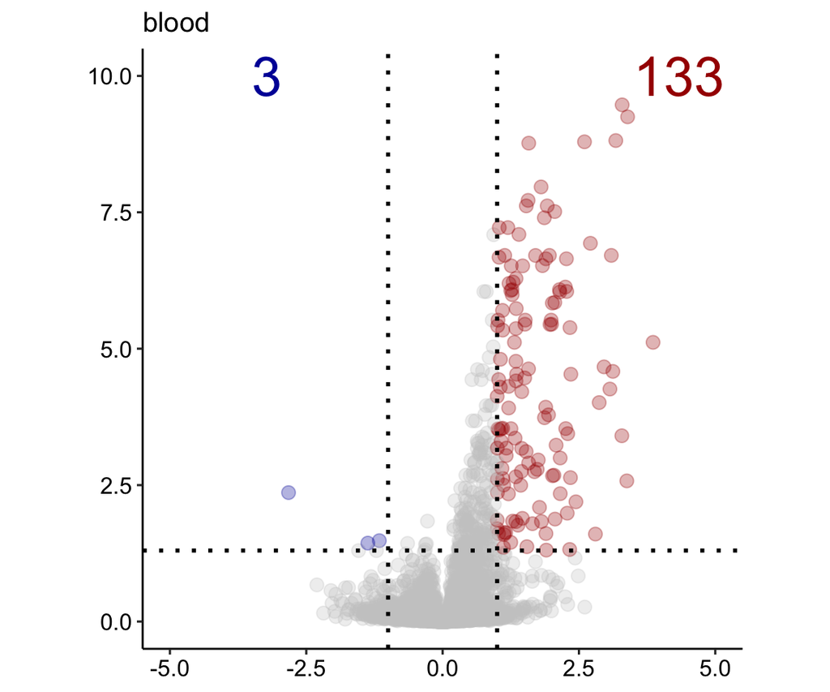

```r
# check only the negative fold change to see if there's a different pahtway of negative fold changes

results_list <- list(res_blood)

names(results_list) <- c("blood")

results_list_plot <- lapply(results_list, function(x) {
  x <- x %>% mutate(
    test_padj = case_when(
      padj < 0.05 & log2FoldChange >= 1 ~ "Up regulated",
      padj < 0.05 & log2FoldChange <= -1 ~ "Down regulated",
      TRUE ~ "Not significant"
    ),
    test_pvalue = case_when(
      pvalue < 0.05 & log2FoldChange >= 1 ~ "Up regulated",
      pvalue < 0.05 & log2FoldChange <= -1 ~ "Down regulated",
      TRUE ~ "Not significant"
    ),
  )
})

# function to make volcano plots
volcano_plot <- function(x) {
  subsetted <- subset(
    results_list_plot[[x]] %>%
      tibble::rownames_to_column("gene_symbol"),
    abs(log2FoldChange) >= 1 & padj < 0.05
  )
  # count up regulated DEGs
  deg_number_up <- subset(
    results_list_plot[[x]] %>%
      tibble::rownames_to_column("gene_symbol"),
    log2FoldChange >= 1 & padj < 0.05
  ) %>%
    nrow()
  # count down regulated DEGs
  deg_number_down <- subset(
    results_list_plot[[x]] %>%
      tibble::rownames_to_column("gene_symbol"),
    log2FoldChange <= -1 & padj < 0.05
  ) %>%
    nrow()
   #results_list_plot[[x]]$genelabels <- ""
   #results_list_plot[[x]]$genelabels <- ifelse(grepl("ISG|CXCL|CD|IL12", results_list_plot[[x]]$gene_symbol), TRUE, FALSE)

  results_list_plot[[x]] %>%
    ggplot(aes(x = log2FoldChange, y = -log10(padj))) +
    geom_point(aes(colour = test_padj), size = 3, alpha = 0.3) +
    scale_color_manual(values = c(
      "Down regulated" = "#0000a6",
      "Not significant" = "grey80",
      "Up regulated" = "#a60000"
    )) +
    xlab(expression("Fold Change (Log"[2] * ")")) +
    ylab(expression("-Log"[10] * "(p-value)")) +
    labs(x = NULL, y = NULL) +
    geom_vline(xintercept = c(-1), linetype = "dotted", size = 1) +
    geom_vline(xintercept = c(1), linetype = "dotted", size = 1) +
    geom_hline(yintercept = -log10(0.05), linetype = "dotted", size = 1) +
    # geom_label_repel(data = subsetted,
    # aes(log2FoldChange,-log10(pvalue),label= gene_symbol),
    # max.overlaps = 10) +
    xlim(-5, 5) +
    ylim(0, 10) +
    ggtitle(x) +
    annotate(
      geom = "text", colour = "#a60000", size = 10, x = 3.5, y = 10, hjust = 0,
      label = paste0(deg_number_up)
    ) +
    annotate(
      geom = "text", colour = "#0000a6", size = 10, x = -3.5, y = 10, hjust = 0,
      label = paste0(deg_number_down)
    ) +
    theme_pubr() +
    theme(legend.position = "none",
          aspect.ratio = 1)
}

volcano_plots <- lapply(names(results_list_plot), volcano_plot)
names(volcano_plots) <- names(results_list_plot)
volcano_plots
```

```r
lapply(names(volcano_plots), function(x) ggsave(filename = paste0(figures.dir,"/", x,"_volcano_plot.pdf"), width = 7, height = 7,
                                         plot = volcano_plots[[x]]))
```

```
## [[1]]
## [1] "../results//2025-03-25/figures/blood_volcano_plot.pdf"
```

### Gene Set Enrichment Analysis with ClusterProfiler

#### Annotaions

```r
# SET THE DESIRED ORGANISM HERE
organism <- "org.Mmu.eg.db"
# BiocManager::install(organism, character.only = TRUE)
library(organism, character.only = TRUE)
```

#### Prepare Input

```r
process_to_gsea <- function(x){
  original_gene_list <- x$log2FoldChange
  names(original_gene_list) <- rownames(x)
  gene_list<-na.omit(original_gene_list)
  gene_list <- sort(gene_list, decreasing = TRUE)
}

ls_processed <- lapply(results_list, process_to_gsea)
```

#### Gene Set Enrichment

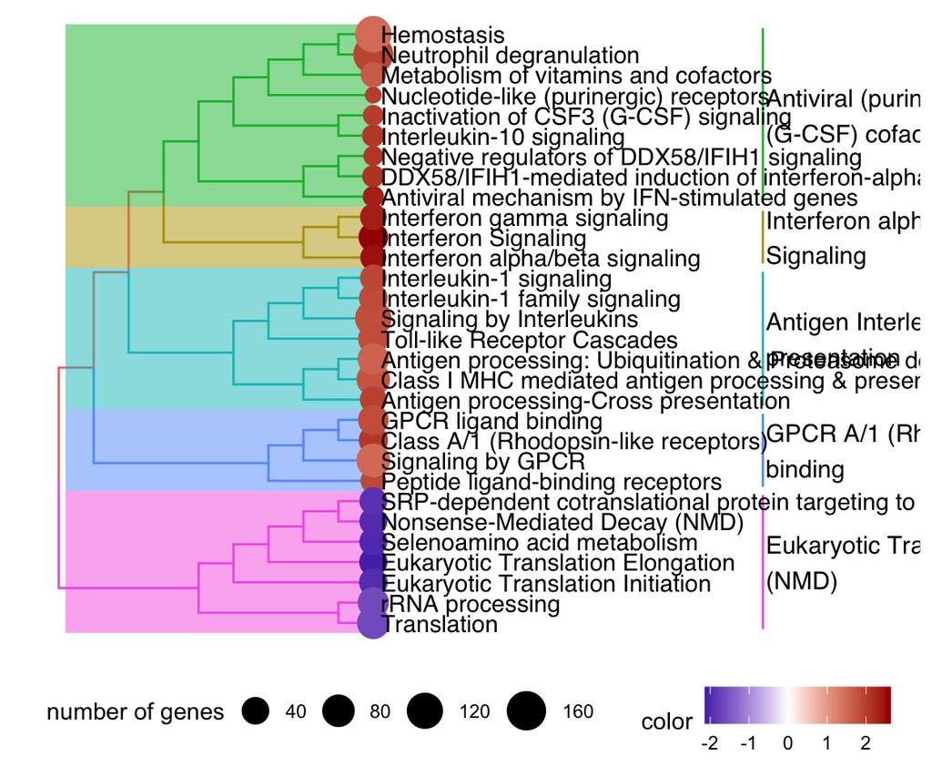

```r
reactome_db <- msigdbr::msigdbr(species = "Macaca mulatta", category = "C2", subcategory = "CP:REACTOME")

list_gse <- lapply(ls_processed, function(x) GSEA(geneList=x,
            TERM2GENE = reactome_db[c("gs_description", "gene_symbol")]
            ))

list_gse <- lapply(list_gse, enrichplot::pairwise_termsim)

treeplot(list_gse[[1]], color = "NES", nwords = 0) +
  theme(legend.position="bottom") +
  scale_color_gradient2(low = "#0000a6", high = "#a60000", mid = "white")
```

```r
ggsave(filename = paste0(figures.dir,"/gsea_reactome_tree.pdf"))
```

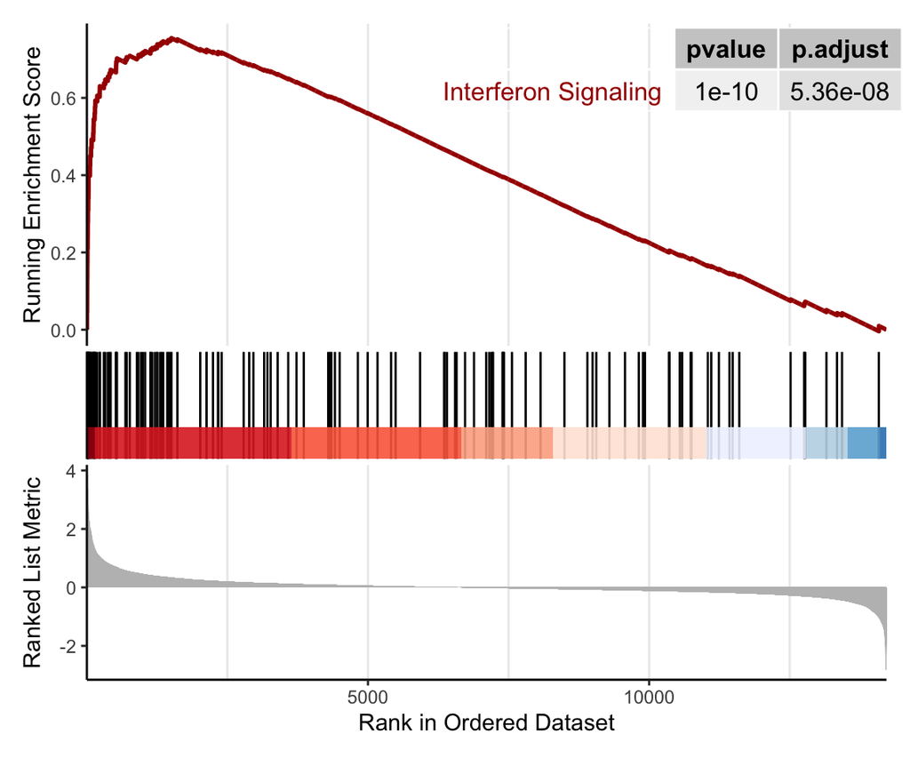

```r
gseaplot2(list_gse[[1]], geneSetID = grep("Interferon Signaling", list_gse[[1]]$Description), pvalue_table = TRUE, color = "#a60000")
```

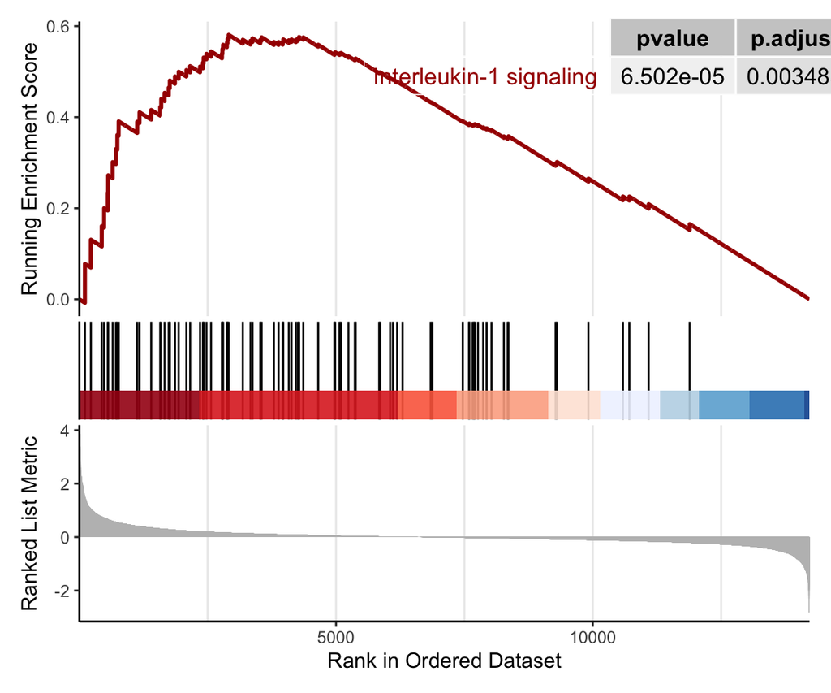

```r
ggsave(filename = paste0(figures.dir,"/gsea_interferon.pdf"), width = 5.7, height = 4)

gseaplot2(list_gse[[1]], geneSetID = grep("Interleukin-1 signaling", list_gse[[1]]$Description), pvalue_table = TRUE, color = "#a60000")
```

```r
ggsave(filename = paste0(figures.dir,"/gsea_interleukin1.pdf"), width = 5.7, height = 4)
```

### Gene Set Variation Analysis

```r
vst_matrix <- assay(dds) %>%
  as.matrix()

reactome_db_interferon <- reactome_db %>% filter(gs_description %in% c("Interferon Signaling","Interleukin-1 signaling" ))


reactome_list <- split(
  reactome_db_interferon$gene_symbol, # The genes we want split into pathways
  reactome_db_interferon$gs_description # The pathways made as the higher levels of the list
)
```

```r
library(corto)

ssgsea_reactome <- corto::ssgsea(inmat = vst_matrix, groups = reactome_list, scale = TRUE)

colnames(ssgsea_reactome) <- colnames(vst_matrix)
ssgsea_reactome_df <- as.data.frame(ssgsea_reactome) %>%
  tibble::rownames_to_column("gs_description") %>%
  # merge all column values to to long format and keep values in column names NES
  tidyr::pivot_longer(c(everything(), -gs_description), names_to = "Sample", values_to = "NES") %>%
  tidyr::separate(Sample, c("Animal.ID", "timepoint"), sep = "_") %>%
  filter(timepoint == "D1") %>%
  merge(fc_biochem, by = "Animal.ID")

for(i in colnames(fc_biochem[-1])){
ssgsea_reactome_df %>%
  ggplot(aes(x = NES, y = get(i))) +
  geom_point() +
    geom_smooth(method = "lm", se = TRUE) +
    stat_cor(method = "pearson", cor.coef.name = "r", p.accuracy = 0.001, label.x.npc = .3) +
    labs(y = i, x = "Normalized Enrichment Score (ssGSEA)") +
    cowplot::theme_cowplot() +
  facet_wrap(~gs_description, scales = "free_x")

ggsave(filename = paste0(figures.dir,"/", i,"_correlation.pdf"), width = 7, height = 5)
}
```

# Compare the gene fold changes with biochmestry fold changes

```r
# calculate the fold changes per sample from the dds object
norm_counts_full <- counts(dds, normalized=TRUE)
# filter for DEGs only
res_blood_sign <- res_blood[!is.na(res_blood$padj) & res_blood$padj < 0.05,]
# filter the counts for the DEGs
norm_counts <- norm_counts_full[rownames(res_blood_sign),]

# calculate the fold change per sample in for all the samples in norm_counts based on the column names where the first characters before "_" are the sample name
sample_names <- gsub("_.*","", colnames(norm_counts))
sample_names <- unique(sample_names)

# calculate the ratio from D1 to D0 for all samples
ratio_nc <- data.frame()
for (i in sample_names){
  print(i)
  # edit the code below to save in a data.frame the ratio that is calculate for all the genes for each
  ratio_nc <- rbind(ratio_nc, tibble(sample = i, ratio = norm_counts_full[,paste0(i,"_D1_PAXgene")]/norm_counts_full[,paste0(i,"_D0_PAXgene")], gene_symbol = rownames(norm_counts_full)))
}
```

```
## [1] "J01"
## [1] "J02"
## [1] "J08"
## [1] "J11"
## [1] "J16"
## [1] "J17"
## [1] "J05"
## [1] "J06"
## [1] "J09"
## [1] "J10"
## [1] "J13"
## [1] "J18"
```

```r
#pivot wider to have the ratio per sample
ratio_nc_wider <- ratio_nc %>%
  tidyr::pivot_wider(names_from = gene_symbol, values_from = ratio )

# order rows of ratio_nc_wider$samples based on order of fc_biochem$Animal.ID
ratio_nc_wider <- ratio_nc_wider[match(fc_biochem$Animal.ID, ratio_nc_wider$sample),]


for(i in c("TNF")){
  data_test <- tibble(ratio_nc_wider[i], fc_biochem["Foldcha_ALT"])

  data_test %>%
    ggplot(aes(x = get(i), y = Foldcha_ALT)) +
    geom_point() +
    geom_smooth(method = "lm", se = TRUE) +
    stat_cor(method = "spearman", cor.coef.name = "r", p.accuracy = 0.001) +
    theme(aspect.ratio = 1) +
    labs(x = paste0(i, "_FC")) +
    theme_bw()

  # save
  ggsave(filename = paste0(figures.dir, "/", i, "_correlation_plot.pdf"), width = 3, height = 3)
}
```

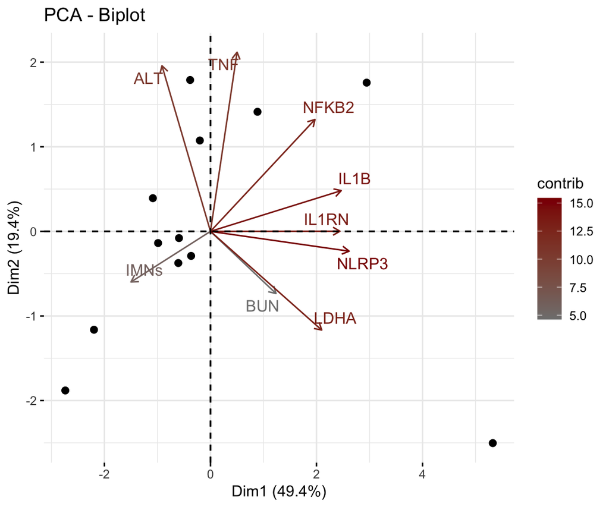

```r
# create a pca using factomine for the gene fold changes in selected_fc and plot
pca_fc <- FactoMineR::PCA(selected_fc[,-1], graph = FALSE)

# plot both vector and ind
fviz_pca_biplot(pca_fc, axes = c(1, 2),
                col.var="contrib",
                pointsize = 2,
                geom = c("point"), gradient.cols = c("grey50", "darkred"),
                repel = TRUE)
```

```r
# save plot
ggsave(filename = paste0(figures.dir,"/pca_fc.pdf"), width = 5, height = 3)
```

## Correlation heatmap

```r
# correlation of genes without Folcha_IMN using corrplot
corr_res <- corr.test(selected_fc[,-c(1,4)],
          ci = TRUE, method = "spearman")

corr_res$p.adj <- matrix(p.adjust(corr_res$p, method = "fdr"),nrow = 8,ncol = 8)
rownames(corr_res$p.adj) <- rownames(corr_res$p)
colnames(corr_res$p.adj) <- colnames(corr_res$p)

# change values to remove diagonal comparisons
# change 0.000000 to 1 (value correlated to itself)
corr_res$p.adj[corr_res$p.adj == 0] <- 1
corr_res$p[corr_res$p == 0] <- 1

# plor corr_res$r and show significant with *
{
  pdf(paste0(figures.dir, "/correlation_plot.pdf"), width = 5, height = 5)
  corrplot::corrplot(corr_res$r, type = "lower",
                     p.mat = corr_res$p.adj, sig.level = c(.001, .01, .05),
                     insig = "label_sig", pch.cex=0.9, pch.col = "white",
                     order = "hclust", tl.col = "black", tl.srt = 45)
  dev.off()
}
```

```r
# not adjusted
{
  pdf(paste0(figures.dir, "/correlation_plot_nopadj.pdf"), width = 5, height = 5)
  corrplot::corrplot(corr_res$r, type = "lower",
                     p.mat = corr_res$p, sig.level = c(.001, .01, .05),
                     insig = "label_sig", pch.cex=0.9, pch.col = "white",
                     order = "hclust", tl.col = "black", tl.srt = 45)
  dev.off()
}
```